# Multi-layer Perceptron

## Lab-Assignment 6

- P.Aneesh
- 16BCE1037

### Abstract:

A multilayer perceptron (MLP) is a class of feedforward artificial neural network. An MLP consists of at least three layers of nodes. Except for the input nodes, each node is a neuron that uses a nonlinear activation function. MLP utilizes a supervised learning technique called backpropagation for training. Its multiple layers and non-linear activation distinguish MLP from a linear perceptron. It can distinguish data that is not linearly separable. Multilayer perceptrons are sometimes colloquially referred to as "vanilla" neural networks, especially when they have a single hidden layer.

### Methodology:

Multi-Layer Perceptrons: The field of artificial neural networks is often just called neural networks or multi-layer perceptrons after perhaps the most useful type of neural network. A perceptron is a single neuron model that was a precursor to larger neural networks. It is a field that investigates how simple models of biological brains can be used to solve difficult computational tasks like the predictive modeling tasks we see in machine learning. The goal is not to create realistic models of the brain, but instead to develop robust algorithms and data structures that we can use to model difficult problems. The power of neural networks come from their ability to learn the representation in your training data and how to best relate it to the output variable that you want to predict. In this sense neural networks learn a mapping. Mathematically, they are capable of learning any mapping function and have been proven to be a universal approximation algorithm. The predictive capability of neural networks comes from the hierarchical or multi-layered structure of the networks. The data structure can pick out (learn to represent) features at different scales or resolutions and combine them into higher-order features. For example from lines, to collections of lines to shapes.

## Dataset:

Given dataset is the wheatSeed dataset which has the following column

- area
- perimeter
- compactness
- lengthOfKernel
- widthOfKernel
- asymmetryCoefficient
- lengthOfKernelGroove
- TypeOfWheatSeed

```python
import pandas as pd
import numpy as np
import matplotlib.pyplot as plt
import sklearn as sk
from sklearn.neural_network import MLPClassifier
from sklearn.model_selection import train_test_split
from sklearn.preprocessing import StandardScaler
from sklearn.metrics import classification_report, accuracy_score
```

```python
col_Names=["area", "perimeter", "compactness", "lengthOfKernel", "widthOfKernel", "asymmetryCoefficient", "lengthOfKernelGroove", "TypeOfWheatSeed"]
data = pd.read_csv("seeds_dataset.csv",names=col_Names, header = None)
```

```python
data.head()
```

|  | area | perimeter | compactness | lengthOfKernel | widthOfKernel | asymmetryCoefficient | lengthOfKernelGroove | TypeOfWheatSeed |
| --- | --- | --- | --- | --- | --- | --- | --- | --- |
| 0 | 15.26 | 14.84 | 0.8710 | 5.763 | 3.312 | 2.221 | 5.220 | 1 |
| 1 | 14.88 | 14.57 | 0.8811 | 5.554 | 3.333 | 1.018 | 4.956 | 1 |
| 2 | 14.29 | 14.09 | 0.9050 | 5.291 | 3.337 | 2.699 | 4.825 | 1 |
| 3 | 13.84 | 13.94 | 0.8955 | 5.324 | 3.379 | 2.259 | 4.805 | 1 |
| 4 | 16.14 | 14.99 | 0.9034 | 5.658 | 3.562 | 1.355 | 5.175 | 1 |

```python
data.isnull().any()
```

```
area                    False
perimeter               False
compactness             False
lengthOfKernel          False
widthOfKernel           False
asymmetryCoefficient    False
lengthOfKernelGroove    False
TypeOfWheatSeed         False
dtype: bool
```

```python
X = data[["area","perimeter","compactness","lengthOfKernel","widthOfKernel","asymmetryCoefficient","lengthOfKernelGroove"]].values
```

```python
Y = data["TypeOfWheatSeed"].values
```

```python
X_train, X_test, y_train, y_test = train_test_split(X, Y, test_size=0.2, random_state=0)
```

```python
scaler = StandardScaler()
scaler.fit(X_train)
X_train = scaler.transform(X_train)
X_test = scaler.transform(X_test)
```

```python
mlpSeed = MLPClassifier(hidden_layer_sizes = (13,13,13), max_iter = 500)
```

```python
mlpSeed.fit(X_train, y_train)
```

```
MLPClassifier(activation='relu', alpha=0.0001, batch_size='auto', beta_1=0.9,
       beta_2=0.999, early_stopping=False, epsilon=1e-08,
       hidden_layer_sizes=(13, 13, 13), learning_rate='constant',
       learning_rate_init=0.001, max_iter=500, momentum=0.9,
       nesterovs_momentum=True, power_t=0.5, random_state=None,
       shuffle=True, solver='adam', tol=0.0001, validation_fraction=0.1,
       verbose=False, warm_start=False)
```

```python
#printing each layers final weights
for i,j in enumerate(mlpSeed.coefs_):
    print("Final Weights for %d layer:\n" %(i+1))
    for ind,val in enumerate(j):
        print("Weights for %d neuron:" %(ind+1))
        print(val)
```

[output not shown]

[output cut: 123 more lines]

[output not shown]

```python
predictions = mlpSeed.predict(X_test)
```

```python
print("Accuracy of predictions: %.2f" %(accuracy_score(y_test, predictions) * 100))
print("Classification Report for the MLP: ")
print(classification_report(y_test, predictions))
```

```
Accuracy of predictions: 92.86
Classification Report for the MLP:
             precision    recall  f1-score   support

          1       0.81      1.00      0.90        13
          2       1.00      0.81      0.90        16
          3       1.00      1.00      1.00        13

avg / total       0.94      0.93      0.93        42
```

## Accuracy/Epoch

```python
graphy=[]
graphx=[]
for epoch in range(250,10000,250):
    mlp = MLPClassifier(hidden_layer_sizes = (15,20,15), max_iter = epoch)
    mlp.fit(X_train, y_train)
    predictions = mlp.predict(X_test)
    graphy.append(accuracy_score(predictions, y_test))
    graphx.append(epoch)
```

```python
d= {'Epoch': graphx,'Accuracy':graphy}
```

```
Text(0.5,0,'Epoch')
```

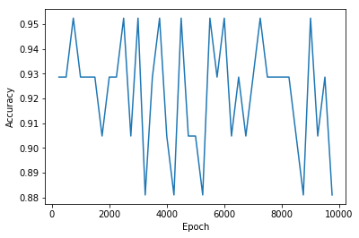

```python
plt.plot("Epoch","Accuracy",data=d)
plt.ylabel('Accuracy')
plt.xlabel('Epoch')
```

```python
print("Number of epoches  accuracy")
for i in range(0,len(graphx)):
    print(graphx[i],"\t",graphy[i])
```

```
Number of epoches  accuracy
250 	 0.9285714285714286
500 	 0.9285714285714286
750 	 0.9523809523809523
1000 	 0.9285714285714286
1250 	 0.9285714285714286
1500 	 0.9285714285714286
1750 	 0.9047619047619048
2000 	 0.9285714285714286
2250 	 0.9285714285714286
2500 	 0.9523809523809523
2750 	 0.9047619047619048
3000 	 0.9523809523809523
3250 	 0.8809523809523809
3500 	 0.9285714285714286
```

[output cut: 25 more lines]

### We an now clearly see that the accuracy is changing based on number of epochs

### We now try changing the number of nodes

```python
graphy=[]
graphx=[]
for nodes in range(1,20,1):
    mlp = MLPClassifier(hidden_layer_sizes = (nodes,nodes,nodes), max_iter = 5000)
    mlp.fit(X_train, y_train)
    predictions = mlp.predict(X_test)
    graphy.append(accuracy_score(predictions, y_test))
    graphx.append(nodes)
```

```
Text(0.5,0,'Node')
```

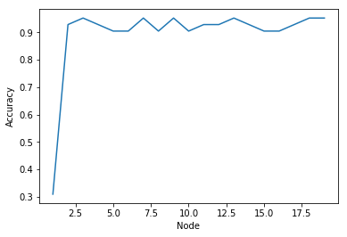

```python
plt.plot(graphx,graphy)
plt.ylabel('Accuracy')
plt.xlabel('Node')
```

```python
print("Number of nodes  accuracy")
for i in range(0,len(graphx)):
    print(graphx[i],"\t",graphy[i])
```

```
Number of nodes  accuracy
1 	 0.30952380952380953
2 	 0.9285714285714286
3 	 0.9523809523809523
4 	 0.9285714285714286
5 	 0.9047619047619048
6 	 0.9047619047619048
7 	 0.9523809523809523
8 	 0.9047619047619048
9 	 0.9523809523809523
10 	 0.9047619047619048
11 	 0.9285714285714286
12 	 0.9285714285714286
13 	 0.9523809523809523
14 	 0.9285714285714286
15 	 0.9047619047619048
16 	 0.9047619047619048
17 	 0.9285714285714286
18 	 0.9523809523809523
19 	 0.9523809523809523
```

### Now we'll try to add more layers to this and see how our accuracy stands up

Now each layers will have 5 nurons/nodes

```python
graphy=[]
graphx=[]
layers=[5]
for nodes in range(1,10,1):
    mlp = MLPClassifier(hidden_layer_sizes = (layers), max_iter = 5000)
    mlp.fit(X_train, y_train)
    predictions = mlp.predict(X_test)
    graphy.append(accuracy_score(predictions, y_test))
    graphx.append(len(layers))
    layers.append(5)
```

```
Text(0.5,0,'Layers')
```

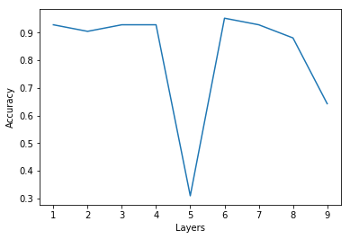

```python
plt.plot(graphx,graphy)
plt.ylabel('Accuracy')
plt.xlabel('Layers')
```

```python
print("Layers  accuracy")
for i in range(0,len(graphx)):
    print(graphx[i],"\t",graphy[i])
```

```
Layers  accuracy
1 	 0.9285714285714286
2 	 0.9047619047619048
3 	 0.9285714285714286
4 	 0.9285714285714286
5 	 0.30952380952380953
6 	 0.9523809523809523
7 	 0.9285714285714286
8 	 0.8809523809523809
9 	 0.6428571428571429
```